# ARIMA

pranit shinde

10 December 2018

## Time series ARIMA( Auto Regressive Integrated Moving Average)

```r
data("AirPassengers")
plot(AirPassengers)
summary(AirPassengers)
```

```
##    Min. 1st Qu.  Median    Mean 3rd Qu.    Max.
##   104.0   180.0   265.5   280.3   360.5   622.0
```

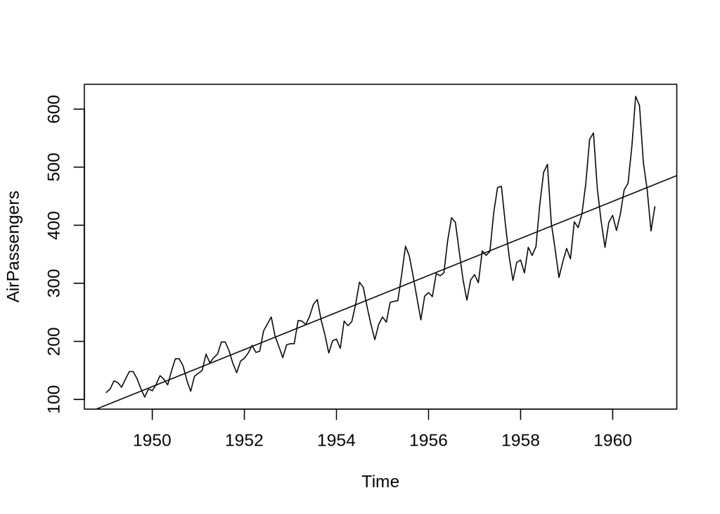

```r
abline(reg = lm(AirPassengers ~ time(AirPassengers)))
```

## the mean for the above plot is not constant, the variance mapped using creast and troughs is also not same above and below the regression line

```r
class(AirPassengers)
```

```
## [1] "ts"
```

```r
start(AirPassengers)  # start of the time series
```

```
## [1] 1949    1
```

```r
end(AirPassengers)  # end of the time series
```

```
## [1] 1960   12
```

```r
frequency(AirPassengers) # cycle of the  time series is 12 month a year
```

```
## [1] 12
```

```r
summary(AirPassengers) # the no of passengers are distributed across the spectrum
```

```
##    Min. 1st Qu.  Median    Mean 3rd Qu.    Max.
##   104.0   180.0   265.5   280.3   360.5   622.0
```

```r
cycle(AirPassengers) ## this print the cycle across year
```

```
##      Jan Feb Mar Apr May Jun Jul Aug Sep Oct Nov Dec
## 1949   1   2   3   4   5   6   7   8   9  10  11  12
## 1950   1   2   3   4   5   6   7   8   9  10  11  12
## 1951   1   2   3   4   5   6   7   8   9  10  11  12
## 1952   1   2   3   4   5   6   7   8   9  10  11  12
## 1953   1   2   3   4   5   6   7   8   9  10  11  12
## 1954   1   2   3   4   5   6   7   8   9  10  11  12
## 1955   1   2   3   4   5   6   7   8   9  10  11  12
## 1956   1   2   3   4   5   6   7   8   9  10  11  12
## 1957   1   2   3   4   5   6   7   8   9  10  11  12
## 1958   1   2   3   4   5   6   7   8   9  10  11  12
## 1959   1   2   3   4   5   6   7   8   9  10  11  12
## 1960   1   2   3   4   5   6   7   8   9  10  11  12
```

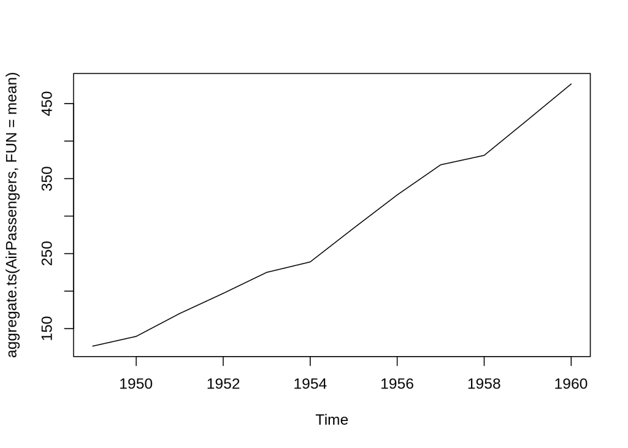

```r
plot(aggregate.ts(AirPassengers, FUN = mean))
```

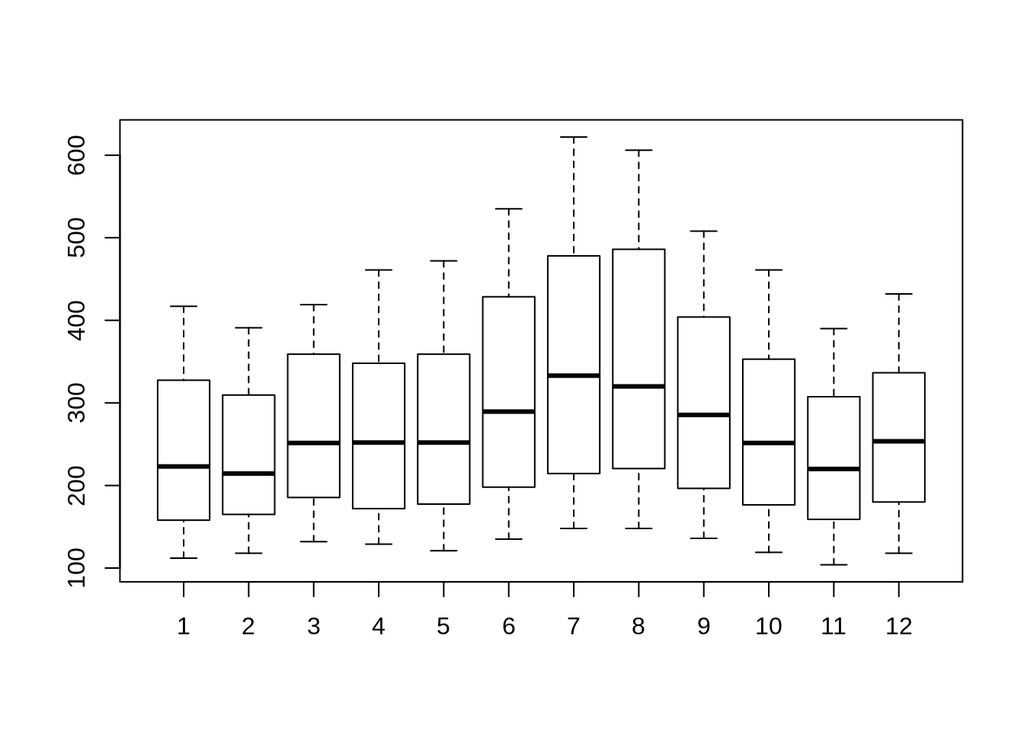

```r
boxplot(AirPassengers ~ cycle(AirPassengers))
```

## To make sure that the variance is constant through time series, we take log of the data

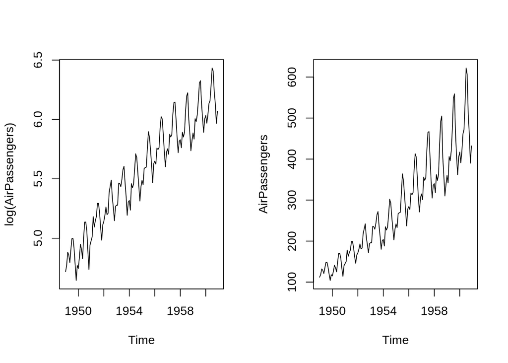

```r
par(mfrow = c(1,2))
plot(log(AirPassengers))
plot(AirPassengers)
```

## To make sure that the mean is constant through the time series , we take the derivative of the log of data

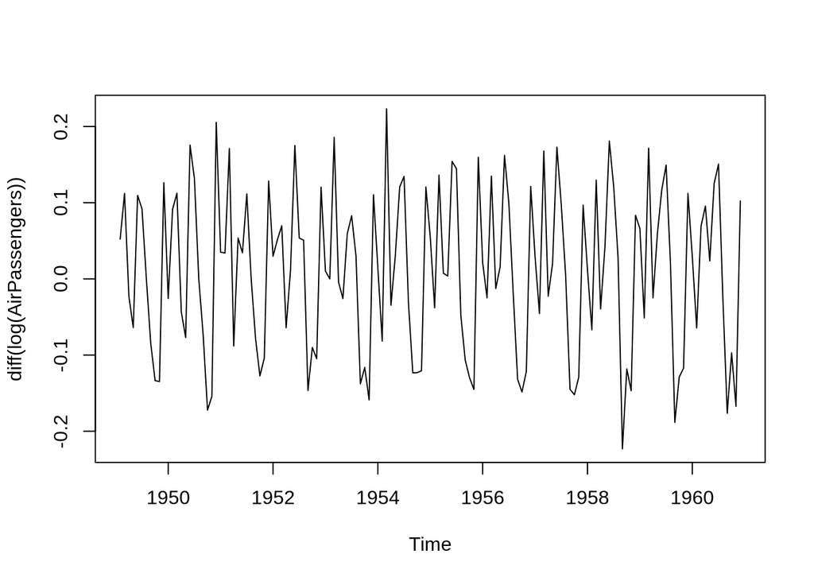

```r
plot(diff(log(AirPassengers)))  # constant mean around zero
```

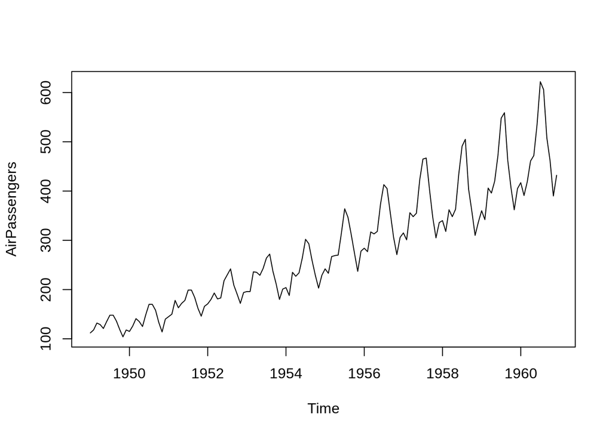

```r
plot(AirPassengers)
```

## p, d and q are three parametersr that are used to build a time series model using ARIMA

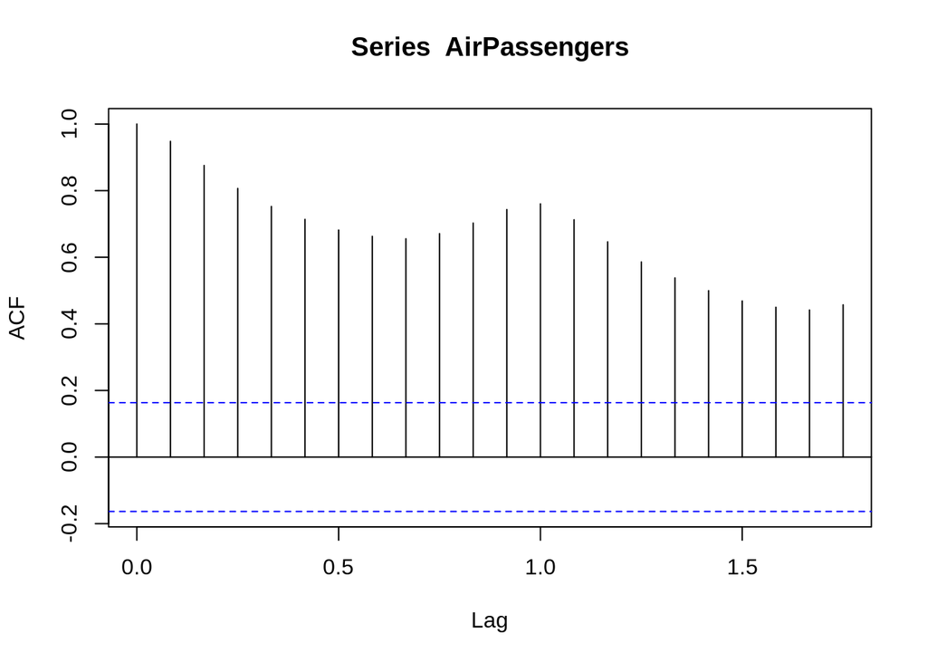

```r
acf(AirPassengers)  ## acf function to be directly applied if the time series is stationary
```

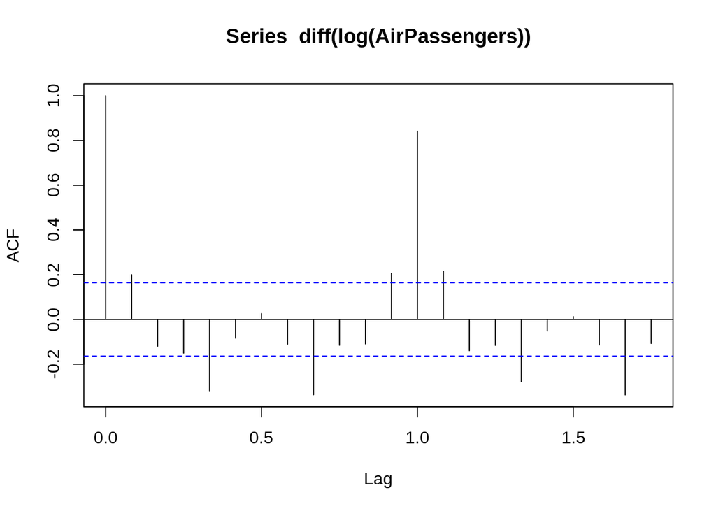

```r
acf(diff(log(AirPassengers)))  ## acf function to be applied after transformation, if the series is
```

```r
                                ## not statinary , this determine the value of q.
```